# Assignment5_EDA

Ajinkya Pawale

10/22/2021

```r
ds = read.csv('curry2015-16.txt',sep=' ',header=TRUE)
```

```r
ds = ds[,c('EVENT_TYPE','SHOT_MADE_FLAG','SHOT_DISTANCE','LOC_X','LOC_Y')]
```

```r
summary(ds)
```

```
##   EVENT_TYPE        SHOT_MADE_FLAG   SHOT_DISTANCE       LOC_X
##  Length:1598        Min.   :0.0000   Min.   : 0.00   Min.   :-250.00
##  Class :character   1st Qu.:0.0000   1st Qu.: 4.00   1st Qu.: -83.25
##  Mode  :character   Median :1.0000   Median :23.00   Median :   2.00
##                     Mean   :0.5038   Mean   :17.37   Mean   :   3.27
##                     3rd Qu.:1.0000   3rd Qu.:25.00   3rd Qu.:  96.75
##                     Max.   :1.0000   Max.   :71.00   Max.   : 250.00
##      LOC_Y
##  Min.   :-21.0
##  1st Qu.: 18.0
##  Median :134.0
##  Mean   :129.2
##  3rd Qu.:223.0
##  Max.   :712.0
```

## Question 1:

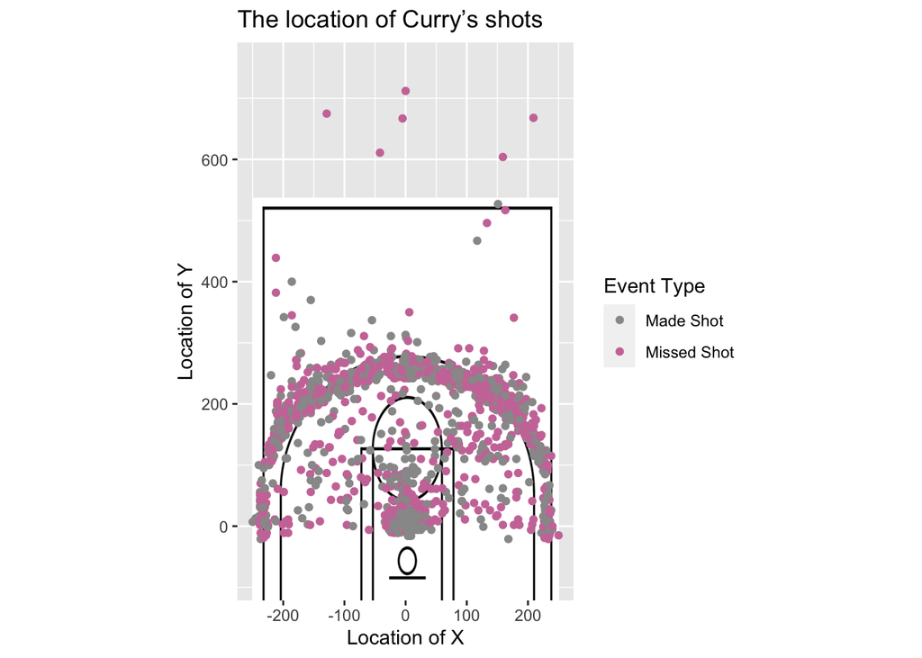

```r
court_img = "https://miro.medium.com/max/1400/1*2QjYg-iJ54sT1ywAoVxtaw.png"
court_final = rasterGrob(readPNG(getURLContent(court_img)),
           width=unit(1,"npc"), height=unit(1.5,"npc"))

ggplot(ds, aes(x=LOC_X, y=LOC_Y)) +
      annotation_custom(court_final, -250, 250, -50, 420) +
      geom_point(aes(colour = EVENT_TYPE)) +
      coord_fixed( xlim = c(-250, 250),
      ylim= c(-80, 750)) + scale_color_manual(values = c("#999999", "#CC79A7")) + xlab('Location of X') + ylab('Location of Y') + labs(color='Event Type') + ggtitle("The location of Curry’s shots")
```

**Conclusion:** As you can see from the above graph that the shot distribution is evenly spread out for both made shot and missed shot. There is no such strong location on the court where the distribution of one is much greater than the other.

## Question 2:

**Plotting the Shot Distance against the Shot Made Flag to see the curve between the two variables. First one considers the Shot Distance enitrely and the second one considers the shot distance <40 as there are less numbers of points after 40.**

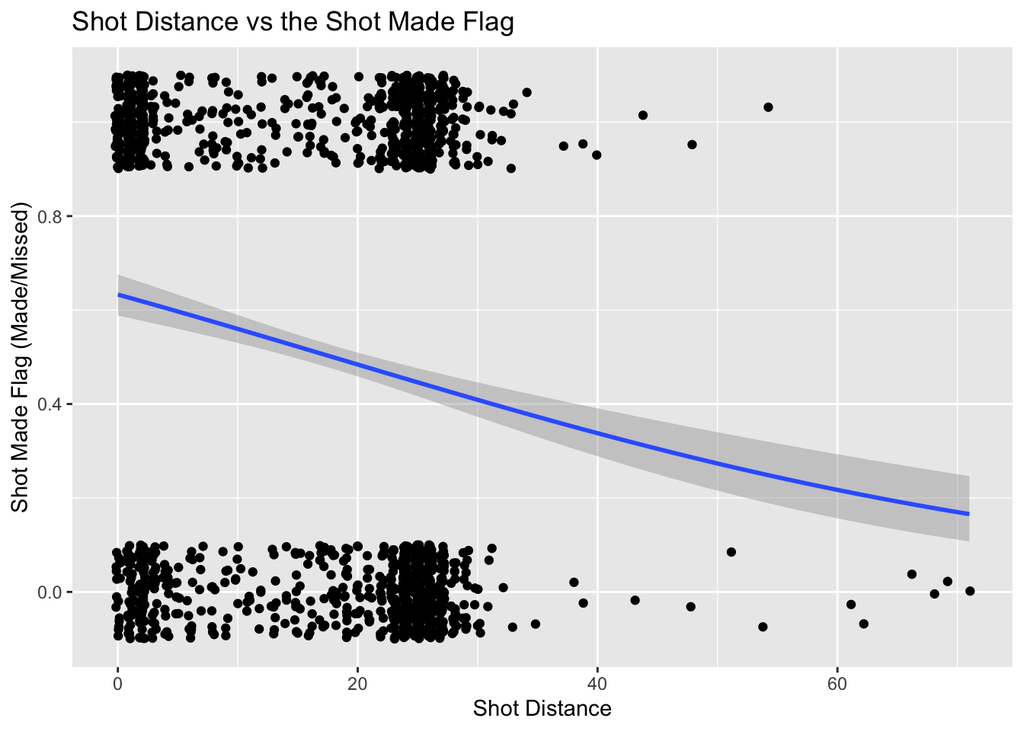

```r
ggplot(ds, aes(x = SHOT_DISTANCE, y = SHOT_MADE_FLAG)) +
geom_jitter(height = 0.1, width = 0.25) +
geom_smooth(method = "glm",
method.args = list(family = "binomial")) + xlab('Shot Distance') + ylab('Shot Made Flag (Made/Missed)') + ggtitle('Shot Distance vs the Shot Made Flag')
```

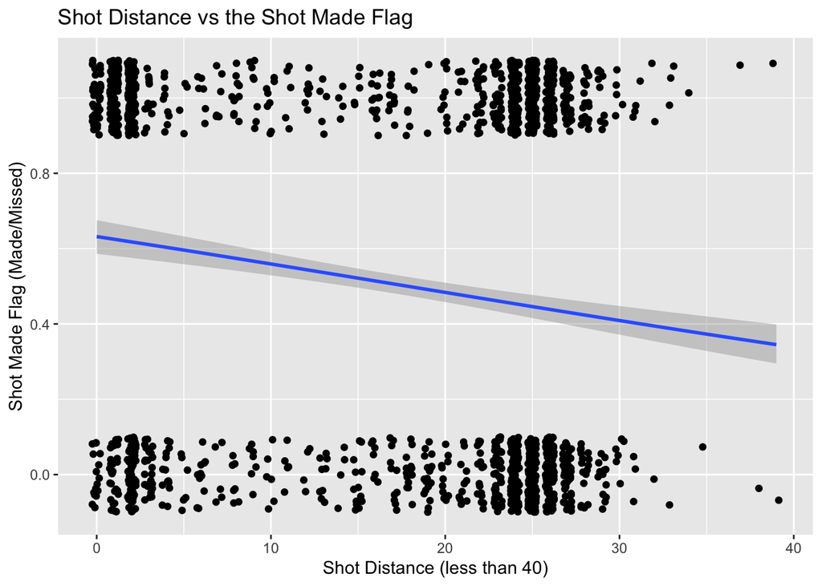

```r
ggplot(filter(ds,SHOT_DISTANCE<40), aes(x = SHOT_DISTANCE, y = SHOT_MADE_FLAG)) +
geom_jitter(height = 0.1, width = 0.25) +
geom_smooth(method = "glm",
method.args = list(family = "binomial")) + xlab('Shot Distance (less than 40)') + ylab('Shot Made Flag (Made/Missed)') + ggtitle('Shot Distance vs the Shot Made Flag')
```

**Conclusion:** The above plot tells us that as the shot distance increases the chances of shot made goes on decreasing or in other words shot is missed, which actually makes sense because logically it should be difficult to get the shot in from a long distance on the court. As you can see for shorter shot distance the Shot Made Flag is towards ‘1’ i.e. Shot Made, which also holds true according to our logic.

**Fitting a logistic regression to predict whether the shot is made, using the single predictor SHOT DISTANCE.**

```r
Target.logit = glm(SHOT_MADE_FLAG ~ SHOT_DISTANCE,
family = binomial, data = ds)
summary(Target.logit)
```

```
##
## Call:
## glm(formula = SHOT_MADE_FLAG ~ SHOT_DISTANCE, family = binomial,
##     data = ds)
##
## Deviance Residuals:
##     Min       1Q   Median       3Q      Max
## -1.4159  -1.0996   0.9563   1.2309   1.6654
##
## Coefficients:
##               Estimate Std. Error z value Pr(>|z|)
## (Intercept)    0.54508    0.09606   5.674 1.39e-08 ***
## SHOT_DISTANCE -0.03045    0.00467  -6.521 6.97e-11 ***
## ---
## Signif. codes:  0 '***' 0.001 '**' 0.01 '*' 0.05 '.' 0.1 ' ' 1
##
## (Dispersion parameter for binomial family taken to be 1)
##
##     Null deviance: 2215.2  on 1597  degrees of freedom
## Residual deviance: 2171.0  on 1596  degrees of freedom
## AIC: 2175
##
## Number of Fisher Scoring iterations: 4
```

Logistic Regression Curve for Single Predictor: **logit[P(Shot_Made_Flag)] = 0.545 - 0.0304 × SHOT_DISTANCE**

## Question 3:

**Plotting the Residuals against the Fitted values for Single Predictor Model**

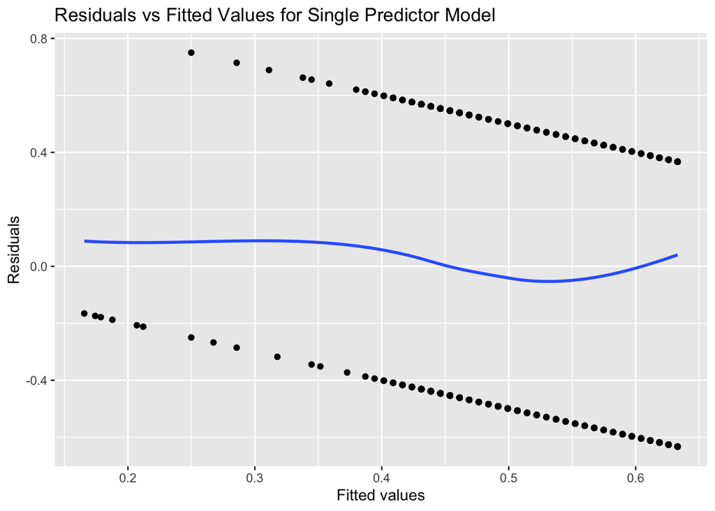

```r
target.model.df = ds
target.model.df$.fitted = fitted.values(Target.logit)
target.model.df$.resid = residuals(Target.logit, type = "response")

ggplot(target.model.df, aes(x = .fitted, y = .resid)) +
geom_point() +
geom_smooth(method = "loess", method.args = list(degree = 1),se=FALSE) +
xlab("Fitted values") + ylab("Residuals") + ggtitle('Residuals vs Fitted Values for Single Predictor Model')
```

**Plotting the Residuals against the Shot Distance**

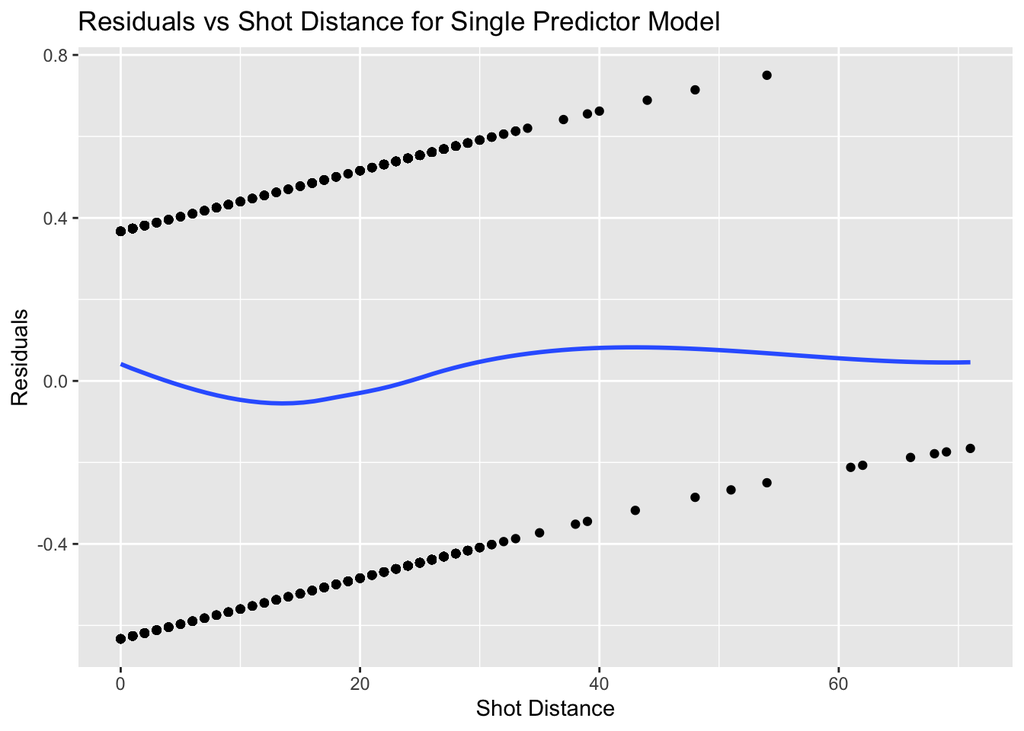

```r
ggplot(target.model.df, aes(x = SHOT_DISTANCE, y = .resid)) +
geom_point() +
geom_smooth(method = "loess", method.args = list(degree = 1),se=FALSE) +
xlab("Shot Distance") + ylab("Residuals") + ggtitle("Residuals vs Shot Distance for Single Predictor Model")
```

**Conclusion:** Here from the above plot we can say that, at the start the model is towards postive residual till a shot distance of around 3, then it goes to negative residual after shot distance of 3 and continues to be negative till 20, after 20 the residual again becomes positive and remains positive till the end. This sudden change of residuals from positive to negative and again positive suggests that the model keeps overestimating and underestimating the values which is not a good indicator.

## Question 4:

**Correlation Plot**

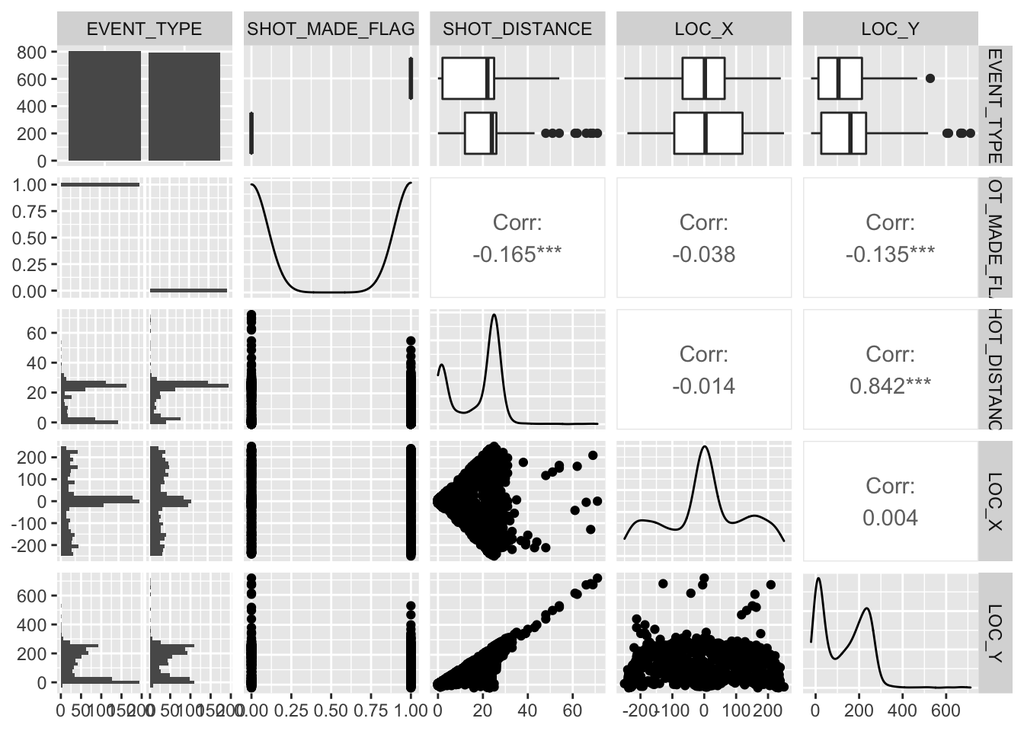

```r
ggpairs(ds)
```

**Fitting a better logistic regression model to predict whether the shot is made, using the predictors SHOT DISTANCE, LOC_X and LOC_Y.**

```r
Target.logit2 = glm(SHOT_MADE_FLAG ~  log(SHOT_DISTANCE+0.1) + LOC_Y + LOC_X,
family = binomial, data = ds)
summary(Target.logit2)
```

```
##
## Call:
## glm(formula = SHOT_MADE_FLAG ~ log(SHOT_DISTANCE + 0.1) + LOC_Y +
##     LOC_X, family = binomial, data = ds)
##
## Deviance Residuals:
##     Min       1Q   Median       3Q      Max
## -1.7691  -1.1068   0.6854   1.2247   1.4053
##
## Coefficients:
##                            Estimate Std. Error z value Pr(>|z|)
## (Intercept)               6.726e-01  1.038e-01   6.478 9.32e-11 ***
## log(SHOT_DISTANCE + 0.1) -2.833e-01  5.287e-02  -5.358 8.42e-08 ***
## LOC_Y                     5.009e-05  6.710e-04   0.075    0.940
## LOC_X                    -5.953e-04  3.960e-04  -1.503    0.133
## ---
## Signif. codes:  0 '***' 0.001 '**' 0.01 '*' 0.05 '.' 0.1 ' ' 1
##
## (Dispersion parameter for binomial family taken to be 1)
##
##     Null deviance: 2215.2  on 1597  degrees of freedom
## Residual deviance: 2152.8  on 1594  degrees of freedom
## AIC: 2160.8
##
## Number of Fisher Scoring iterations: 4
```

Logistic Regression Curve for Multiple Predictor: **logit[P(Shot_Made_Flag)] = 0.672 - 0.283 × log(SHOT_DISTANCE+0.1) + 0.00005 x LOC_Y - 0.000595 x LOC_X**

**Plot of Residuals vs Fitted values for multiple predictors**

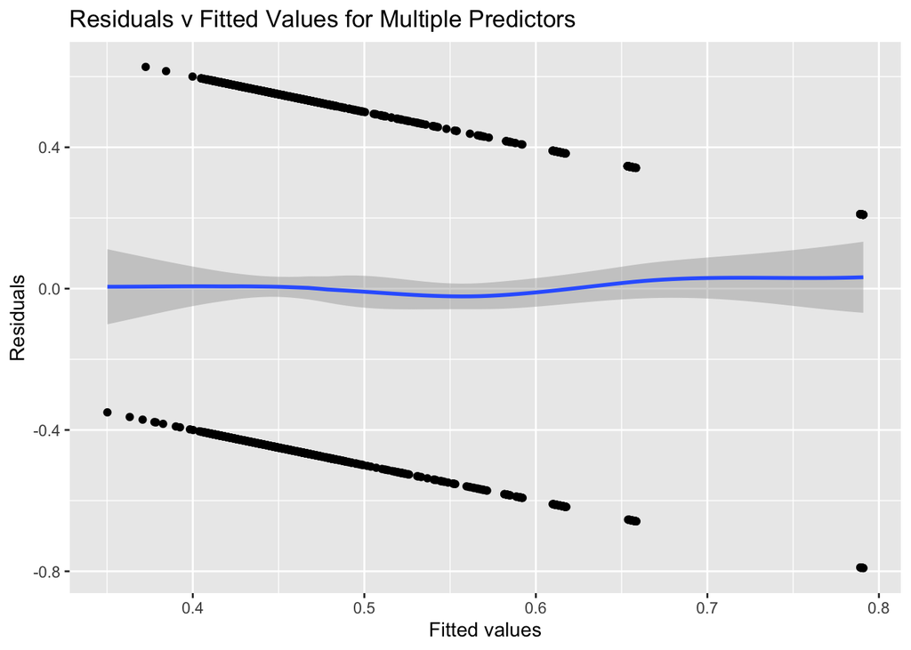

```r
target.model.df2 = ds
target.model.df2$.fitted = fitted.values(Target.logit2)
target.model.df2$.resid = residuals(Target.logit2, type = "response")

ggplot(target.model.df2, aes(x = .fitted, y = .resid)) +
geom_point() +
geom_smooth(method = "loess", method.args = list(degree = 1)) +
xlab("Fitted values") + ylab("Residuals") + ggtitle("Residuals v Fitted Values for Multiple Predictors")
```

**Plot of residuals vs Lcoation Y for multiple predictors**

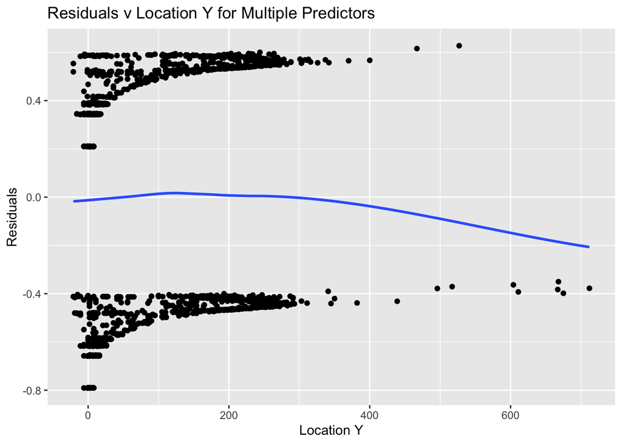

```r
ggplot(target.model.df2, aes(x = LOC_Y, y = .resid)) +
geom_point() +
geom_smooth(method = "loess", method.args = list(degree = 1),se=FALSE) +
xlab("Location Y") + ylab("Residuals") + ggtitle("Residuals v Location Y for Multiple Predictors")
```

**Plot of residuals vs Location X for multiple predictors**

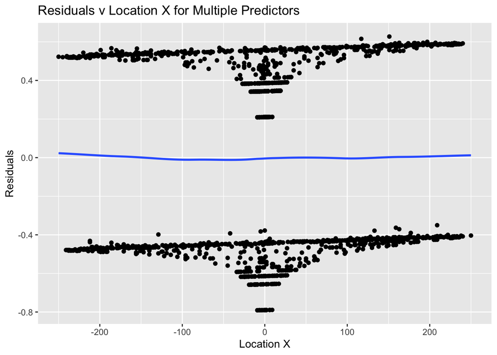

```r
ggplot(target.model.df2, aes(x = LOC_X, y = .resid)) +
geom_point() +
geom_smooth(method = "loess", method.args = list(degree = 1),se=FALSE) +
xlab("Location X") + ylab("Residuals") + ggtitle("Residuals v Location X for Multiple Predictors")
```

**Plot of residuals vs Shot Distance for multiple predictors**

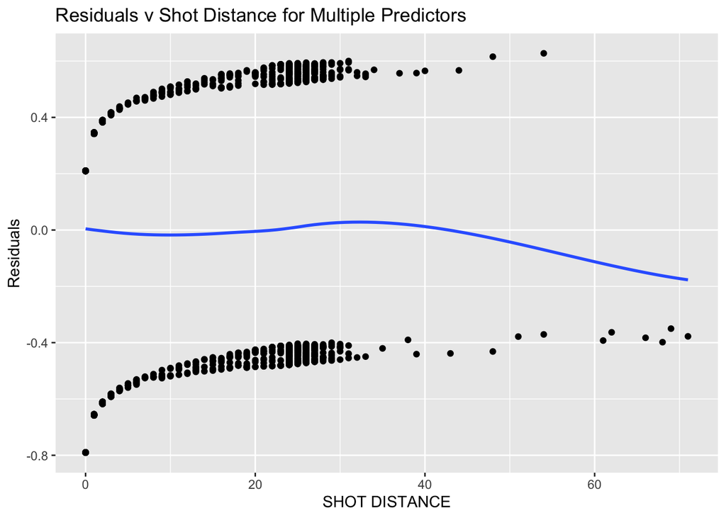

```r
ggplot(target.model.df2, aes(x = SHOT_DISTANCE, y = .resid)) +
geom_point() +
geom_smooth(method = "loess", method.args = list(degree = 1),se=FALSE) +
xlab("SHOT DISTANCE") + ylab("Residuals") + ggtitle("Residuals v Shot Distance for Multiple Predictors")
```